# R Notebook

Whenever you perform a one-way ANOVA, you will always compute three sum of squares values:

1. Treatment Sum of Squares (SST)

   This is the sum of the squared differences between each group mean and the grand mean.
2. Within Group Sum of Squares (SSE)

   This is the sum of the squared differences between each individual observation and the group mean of that observation.
3. Total Sum of Squares (TSS)

   This is the sum of the squared differences between each individual observation and the grand mean.
4. Sum of Squares Total (SST) SST = SST + SSE

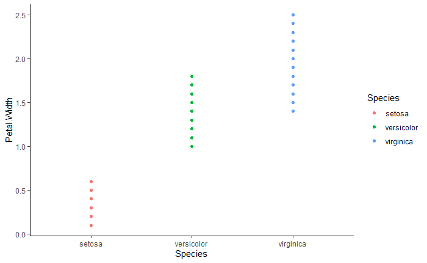

```r
library(ggplot2)
library(dplyr)
iris %>% ggplot(aes(x = Species,y = Petal.Width, color = Species)) + geom_point() + theme_classic()
```

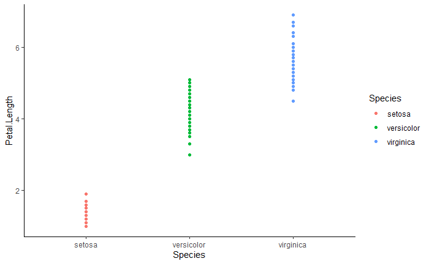

```r
iris %>% ggplot(aes(x = Species,y = Petal.Length, color = Species)) + geom_point() + theme_classic()
```

```r
# Analysis of Variance calculation

sepal_aov <- aov(Sepal.Length ~ Species, data = iris)
summary(sepal_aov)
```

```
             Df Sum Sq Mean Sq F value Pr(>F)
Species       2  63.21  31.606   119.3 <2e-16 ***
Residuals   147  38.96   0.265
---
Signif. codes:  0 ‘***’ 0.001 ‘**’ 0.01 ‘*’ 0.05 ‘.’ 0.1 ‘ ’ 1
```

With a low p-value we reject the null hypothesis that there is no variance and accept the alternate hypothesis.

```r
petal_aov <- aov(Petal.Width ~ Species, data = iris)
summary(petal_aov)
```

```
             Df Sum Sq Mean Sq F value Pr(>F)
Species       2  80.41   40.21     960 <2e-16 ***
Residuals   147   6.16    0.04
---
Signif. codes:  0 ‘***’ 0.001 ‘**’ 0.01 ‘*’ 0.05 ‘.’ 0.1 ‘ ’ 1
```

For ANOVA testing the samples must be equal Tukey Significance test: taking the ANOVA and analyzing each factor seperately

```r
TukeyHSD(sepal_aov)
```

```
  Tukey multiple comparisons of means
    95% family-wise confidence level

Fit: aov(formula = Sepal.Length ~ Species, data = iris)

$Species
                      diff       lwr       upr p adj
versicolor-setosa    0.930 0.6862273 1.1737727     0
virginica-setosa     1.582 1.3382273 1.8257727     0
virginica-versicolor 0.652 0.4082273 0.8957727     0
```

```r
TukeyHSD(petal_aov)
```

```
  Tukey multiple comparisons of means
    95% family-wise confidence level

Fit: aov(formula = Petal.Width ~ Species, data = iris)

$Species
                     diff       lwr       upr p adj
versicolor-setosa    1.08 0.9830903 1.1769097     0
virginica-setosa     1.78 1.6830903 1.8769097     0
virginica-versicolor 0.70 0.6030903 0.7969097     0
```

Two-way ANOVA: Analyze 2 categorical variables against 1 continuous variable

| Observation | Gender | Dosage | Alertness |
| --- | --- | --- | --- |
| 1 | m | a | 8 |
| 2 | m | a | 12 |
| 3 | m | a | 13 |
| 4 | m | a | 12 |
| 5 | m | b | 6 |
| 6 | m | b | 7 |
| 7 | m | b | 23 |
| 8 | m | b | 14 |
| 9 | f | a | 15 |
| 10 | f | a | 12 |

[output cut: 6 more lines]

Analyzing weather dosage changes made a difference in alertness between men and women

```r
two_way <- aov(Alertness~ Gender + Dosage,data = data.ex2)
summary(two_way)
```

```
            Df Sum Sq Mean Sq F value Pr(>F)
Gender       1  76.56   76.56   3.197 0.0971 .
Dosage       1   5.06    5.06   0.211 0.6533
Residuals   13 311.31   23.95
---
Signif. codes:  0 ‘***’ 0.001 ‘**’ 0.01 ‘*’ 0.05 ‘.’ 0.1 ‘ ’ 1
```

Cannot reject the null hypothesis that there is no variance with p value greater than 0.05